**DAN HARGREAVES** - DATA SCIENCE PORTFOLIO

# NEW YORK TAXI FARE PREDICTION

## INTRODUCTION

The goal in this Kaggle competition was to predict the taxi fares paid by customers in New York using a large data set of historical transactions. The raw data came with the following features:

- key
- fare_amount
- pickup_datetime
- pickup_longitude
- pickup_latitude
- dropoff_longitude
- dropoff_latitude
- passenger_count

We will initally build a simple linear model with a distance feature calculated from the absolute distance between the longitude and latitudes of the pickup and drop off points respectivley. This will serve as a benchmark to see if we can use additional feature engineering and a more advanced machine learning algorithm to improve on the results.

## IMPORT LIBRARIES & DATA

**IMPORT STANDARD PYTHON LIBRARIES**

```python
import pandas as pd
import numpy as np
import matplotlib.pyplot as plt
import seaborn as sns
%matplotlib inline
pd.set_option('display.max_columns', None)
import warnings
warnings.filterwarnings('ignore')
```

**IMPORT DATA & SAMPLE**

Given the large dataset that was provided for training a model using a sample of 1% allowed faster development time while still leaving enough transactions to capture much of the variance within the data.

```python
train_original = pd.read_csv('train.csv')
data = train_original.sample(frac=0.01,random_state=1)
```

**INITIAL DATA EXPLORATION**

```python
data.head()
```

|  | key | fare_amount | pickup_datetime | pickup_longitude | pickup_latitude | dropoff_longitude | dropoff_latitude | passenger_count |
| --- | --- | --- | --- | --- | --- | --- | --- | --- |
| 18405712 | 2010-01-08 22:33:37.0000001 | 4.5 | 2010-01-08 22:33:37 UTC | -73.970033 | 40.756524 | -73.961678 | 40.765214 | 1 |
| 23699354 | 2011-08-11 17:02:30.0000004 | 9.7 | 2011-08-11 17:02:30 UTC | -73.974122 | 40.750896 | -73.952719 | 40.782441 | 1 |
| 35661978 | 2012-09-14 17:39:00.000000122 | 12.5 | 2012-09-14 17:39:00 UTC | -74.002213 | 40.726405 | -74.001880 | 40.737742 | 1 |
| 14056497 | 2014-05-03 10:08:44.0000001 | 6.5 | 2014-05-03 10:08:44 UTC | -74.003474 | 40.726925 | -73.988778 | 40.739565 | 1 |
| 31198457 | 2014-09-20 22:19:55.0000002 | 3.0 | 2014-09-20 22:19:55 UTC | -73.992241 | 40.759311 | -73.993850 | 40.761915 | 1 |

```python
data.dtypes
```

```
key                   object
fare_amount          float64
pickup_datetime       object
pickup_longitude     float64
pickup_latitude      float64
dropoff_longitude    float64
dropoff_latitude     float64
passenger_count        int64
dtype: object
```

```python
data.describe()
```

|  | fare_amount | pickup_longitude | pickup_latitude | dropoff_longitude | dropoff_latitude | passenger_count |
| --- | --- | --- | --- | --- | --- | --- |
| count | 554239.000000 | 554239.000000 | 554239.000000 | 554234.000000 | 554234.000000 | 554239.000000 |
| mean | 11.326722 | -72.493329 | 39.919650 | -72.526574 | 39.917517 | 1.684871 |
| std | 9.749933 | 13.433530 | 7.635086 | 14.203965 | 10.766350 | 1.337977 |
| min | -75.000000 | -2534.726347 | -2117.944373 | -3379.115687 | -2877.122115 | 0.000000 |
| 25% | 6.000000 | -73.992043 | 40.734983 | -73.991415 | 40.734042 | 1.000000 |
| 50% | 8.500000 | -73.981824 | 40.752616 | -73.980145 | 40.753117 | 1.000000 |
| 75% | 12.500000 | -73.967051 | 40.767080 | -73.963666 | 40.768093 | 2.000000 |
| max | 475.000000 | 3439.425565 | 1595.451800 | 2039.915613 | 3537.132528 | 208.000000 |

#### CHECK FOR NULL VALUES

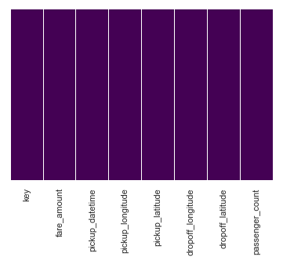

```python
sns.heatmap(data.isnull(),yticklabels=False,cbar=False,cmap='viridis')
```

```python
data.info()
```

```
<class 'pandas.core.frame.DataFrame'>
Int64Index: 554239 entries, 18405712 to 49758658
Data columns (total 8 columns):
key                  554239 non-null object
fare_amount          554239 non-null float64
pickup_datetime      554239 non-null object
pickup_longitude     554239 non-null float64
pickup_latitude      554239 non-null float64
dropoff_longitude    554234 non-null float64
dropoff_latitude     554234 non-null float64
passenger_count      554239 non-null int64
dtypes: float64(5), int64(1), object(2)
memory usage: 38.1+ MB
```

#### SPLIT DATA INTO TRAIN & TEST SET

```python
from sklearn.model_selection import train_test_split
train, test = train_test_split(data,test_size=0.4, random_state=101)
```

**REMOVE OUTLIERS & POTENTIAL ERRORS**

The data contained pickup locations or dropoff locations that were well outside the New York area and so removing these outliers should ensure the model concentrates on accuracy in the most likely scenarios. In addition some training examples have a 0 distance value which appear to be potential errors.

```python
train = train[train['pickup_longitude'] > -75]
train = train[train['pickup_longitude'] < -73]
train = train[train['pickup_latitude'] > 40]
train = train[train['pickup_latitude'] <= 41]
train.dropna(inplace=True)
test.dropna(inplace=True)
```

## CREATE BENCHMARK MODEL

Here we will create a simple linear regression model using a distance feature created from the absolute distance between the longitude and latitudes of the pickup and drop off points. This will serve as a benchmark for the more complex model we will create later.

```python
train_bm = train
test_bm = test
train_bm['distance'] = (np.absolute(train_bm['pickup_longitude'] - train_bm['dropoff_longitude']) +
                        np.absolute(train_bm['pickup_latitude'] - train_bm['dropoff_latitude']))
test_bm['distance'] = (np.absolute(test_bm['pickup_longitude'] - test_bm['dropoff_longitude']) +
                        np.absolute(test_bm['pickup_latitude'] - test_bm['dropoff_latitude']))
```

```python
X_train_bm = train_bm['distance']
y_train_bm = train_bm['fare_amount']
X_test_bm = test['distance']
y_test_bm = test['fare_amount']
```

```python
X_train_bm = X_train_bm.values.reshape(-1, 1)
from sklearn.linear_model import LinearRegression
lm = LinearRegression()
lm.fit(X_train_bm, y_train_bm)
```

```
LinearRegression(copy_X=True, fit_intercept=True, n_jobs=None,
         normalize=False)
```

```python
X_test_bm = X_test_bm.values.reshape(-1, 1)
predictions_bm = lm.predict(X_test_bm)
```

```python
from sklearn.metrics import mean_absolute_error, mean_squared_error
from math import sqrt
print('Test MAE: ' + str(mean_absolute_error(y_test_bm, predictions_bm)))
print('Test RMSE: ' + str(sqrt(mean_squared_error(y_test_bm, predictions_bm))))
```

```
Test MAE: 6.035932813825844
Test RMSE: 9.763904267646785
```

Our benchmark to beat with our complex model is \$9.76

## CREATE INITIAL NEW FEATURES & REMOVE OUTLIERS

Initially after thinking through the problem and seeing the included features it is obvious that there are additional features we can create from the included features that could be predictive of the fare a customer paid:

- The distance and direction of travel between a pickup and dropoff location
- The time of day, day of week and month
- The area of the city a customer was picked up from or dropped off rather than using a single point location

**CREATE DISTANCE FEATURE**

To determine the distance between the pickup and drop off points we can create a new feature by writing a function that uses the pickup and dropoff coordinates to calculate the geodesic distance.

```python
from math import sin, cos, sqrt, atan2, radians, degrees
def get_distance(x1,x2,x3,x4):
    R = 6373.0
    lat1 = radians(x1)
    lon1 = radians(x2)
    lat2 = radians(x3)
    lon2 = radians(x4)
    dlon = lon2 - lon1
    dlat = lat2 - lat1
    a = sin(dlat / 2)**2 + cos(lat1) * cos(lat2) * sin(dlon / 2)**2
    c = 2 * atan2(sqrt(a), sqrt(1 - a))
    distance = R * c
    return distance

train['distance'] = train.apply(lambda x: get_distance(x['pickup_latitude'],x['pickup_longitude'],
     x['dropoff_latitude'],x['dropoff_longitude']), axis=1)
test['distance'] = test.apply(lambda x: get_distance(x['pickup_latitude'],x['pickup_longitude'],
     x['dropoff_latitude'],x['dropoff_longitude']), axis=1)
```

**CREATE BEARING FEATURE**

Using a similar methodology to creating the distance feature, we create a bearing feature that describes the direction of travel and then assign this to one of eight groupings that are 45 degrees apart.

```python
def get_bearing(x1,x2,x3,x4):
    lat1 = radians(x1)
    lon1 = radians(x2)
    lat2 = radians(x3)
    lon2 = radians(x4)
    dlon = lon2 - lon1
    x = sin(dlon) * cos(lat2)
    y = cos(lat1) * sin(lat2) - sin(lat1) * cos(lat2) * cos(dlon)
    bearing = (degrees(atan2(x, y)) + 360) % 360
    return bearing

train['bearing'] = train.apply(lambda x: get_bearing(x['pickup_latitude'],x['pickup_longitude'],
     x['dropoff_latitude'],x['dropoff_longitude']), axis=1)
test['bearing'] = test.apply(lambda x: get_bearing(x['pickup_latitude'],x['pickup_longitude'],
     x['dropoff_latitude'],x['dropoff_longitude']), axis=1)
```

```python
train['bearing_cat'] = train['bearing'].apply(lambda x: 'be_1' if x > 315 else 'be_2' if
                      x > 270 else 'be_3' if x > 225 else'be_4' if x > 180  else 'be_5' if x > 135
                      else 'be_6' if x > 90 else 'be_7' if x > 45 else 'be_8' )
test['bearing_cat'] = test['bearing'].apply(lambda x: 'be_1' if x > 315 else 'be_2' if
                      x > 270 else 'be_3' if x > 225 else'be_4' if x > 180  else 'be_5' if x > 135
                      else 'be_6' if x > 90 else 'be_7' if x > 45 else 'be_8' )
```

**CREATE DATE & TIME FEATURES**

We can use Python datetime library to extract day, hour and month features

```python
import datetime as dt
train['pickup_datetime'] = pd.to_datetime(train['pickup_datetime'])
train['day'] = train['pickup_datetime'].dt.dayofweek
train['hour'] = train['pickup_datetime'].dt.hour
train['month'] = train['pickup_datetime'].dt.month
test['pickup_datetime'] = pd.to_datetime(test['pickup_datetime'])
test['day'] = test['pickup_datetime'].dt.dayofweek
test['hour'] = test['pickup_datetime'].dt.hour
test['month'] = test['pickup_datetime'].dt.month
```

## CLUSTERING

The pickup and dropoff locations are given as coordinates and therefore are continous values which are unsuitable for modelling purposes. To get around this we will cluster these locations into 50 groups that should represent different areas around New York.

To do this we will use the K-means clustering algorithm to generate the clusters on a subset of the train dataset and then use a K-Nearest Neighbours algorithm to assign clusters to the test set. The K-Nearest Neighbours alorigthm is usually fast to train and works well when dealing with location data.

#### Pickup Locations Before Clustering

[figure not shown]

#### Generate Location Clusters from Pickup Co-ordinates

```python
from sklearn.cluster import KMeans
coordinates = train[['pickup_longitude', 'pickup_latitude']]
k_means = KMeans(n_clusters=50)
k_means.fit(coordinates)
```

```
KMeans(algorithm='auto', copy_x=True, init='k-means++', max_iter=300,
    n_clusters=50, n_init=10, n_jobs=None, precompute_distances='auto',
    random_state=None, tol=0.0001, verbose=0)
```

#### Cluster Centres

[figure not shown]

#### CREATE A DATASET THAT INCLUDES ASSIGNED CLUSTER LABELS

```python
labels = pd.Series(k_means.labels_)
train.reset_index(inplace=True, drop=True)
location_clusters = pd.concat([train[['pickup_longitude', 'pickup_latitude']],labels], axis=1)
location_clusters.rename(columns={0: "pick_cluster" }, inplace=True)
```

#### SPLIT THE ASSIGNED DATASET INTO A TRAINING AND TEST SETS

```python
X_clusters = location_clusters[['pickup_longitude', 'pickup_latitude']]
y_clusters = location_clusters['pick_cluster']
X_train_clusters, X_test_clusters, y_train_clusters, y_test_clusters = train_test_split(X_clusters,y_clusters,
                                                                                          test_size=0.4, random_state=101)
```

#### TRAIN THE K-NEAREST NEIGHBOURS ALGORITHM TO ASSIGN CLUSTERS

```python
from sklearn.neighbors import KNeighborsClassifier
location_cluster_model = KNeighborsClassifier(n_neighbors=50, weights='distance')
location_cluster_model.fit(X_train_clusters, y_train_clusters)
```

```
KNeighborsClassifier(algorithm='auto', leaf_size=30, metric='minkowski',
           metric_params=None, n_jobs=None, n_neighbors=50, p=2,
           weights='distance')
```

#### ASSIGN CLUSTERS TO X_TEST_CLUSTERS DATA SET AND MEASURE ACCURACY

```python
cluster_pred_test = location_cluster_model.predict(X_test_clusters)
```

```python
from sklearn import metrics
print("Cluster Prediction Accuracy:",metrics.accuracy_score(y_test_clusters, cluster_pred_test))
```

```
Cluster Prediction Accuracy: 0.9948032209283582
```

The K-Nearest Neighbours algorithm has a 99% accuracy in assigning cluster labels on the cluster test set.

#### FUNCTION TO ASSIGN CLUSTER BASED ON LOCATION COORDINATES

```python
def assign_clusters(data, coordinates,cluster_model):
    clusters = cluster_model.predict(coordinates)
    clusters = pd.Series(clusters)
    data.reset_index(inplace=True, drop=True)
    data = pd.concat([data, clusters], axis=1)
    return data
```

#### ASSIGN A PICKUP CLUSTER LOCATION TO EACH TRAINING AND TEST EXAMPLE

```python
train = assign_clusters(train, train[['pickup_longitude', 'pickup_latitude']], location_cluster_model)
train.rename(columns={0:'pick_cluster'}, inplace=True)
test = assign_clusters(test, test[['pickup_longitude', 'pickup_latitude']], location_cluster_model)
test.rename(columns={0:'pick_cluster'}, inplace=True)
```

#### ASSIGN A DROPOFF CLUSTER LOCATION TO EACH TRAINING AND TEST EXAMPLE

```python
train = assign_clusters(train, train[['dropoff_longitude', 'dropoff_latitude']], location_cluster_model)
train.rename(columns={0:'drop_cluster'}, inplace=True)
test = assign_clusters(test, test[['dropoff_longitude', 'dropoff_latitude']], location_cluster_model)
test.rename(columns={0:'drop_cluster'}, inplace=True)
```

## VISUALISATION

**HEATMAP $ PER KM BY PICKUP LOCATION CLUSTER BY HOUR**

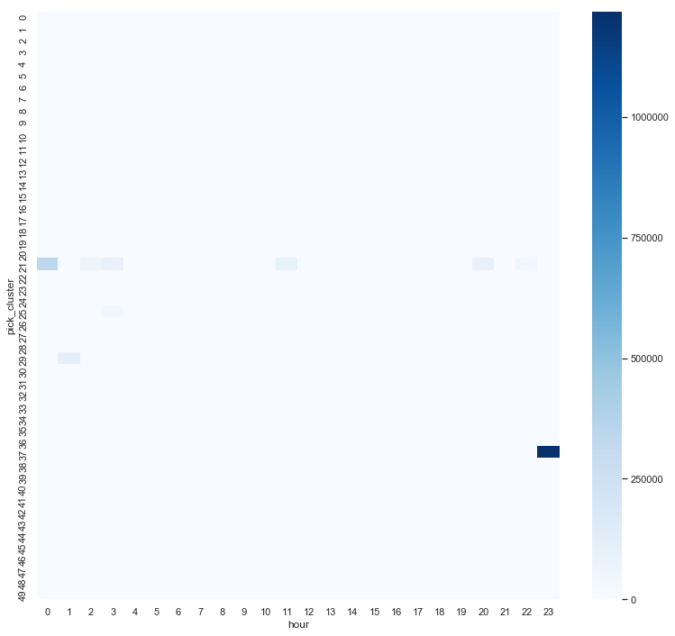

```python
cat = train.groupby(['pick_cluster', 'hour'],as_index=False)['fare_amount','distance'].agg(['sum']).reset_index()
cnt = train.groupby(['pick_cluster'])['pick_cluster'].agg(['count']).reset_index()
cat.columns = cat.columns.droplevel(1)
cat = cat[cat['distance'] > 0]
cat['per_km'] = cat['fare_amount']/cat['distance']
#cat = cat[(cat['pick_cluster'] == 3) | (cat['pick_cluster'] == 6)]
cat_pivot = cat.pivot(index='pick_cluster', columns='hour', values='per_km')
cat_pivot.fillna(0, inplace=True)
plt.figure(figsize=(13,12))
sns.heatmap(cat_pivot,cmap='Blues')
```

**HEATMAP HEATMAP $ PER KM BY DAY BY HOUR**

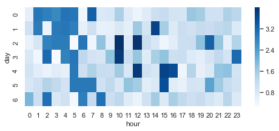

```python
cat = train.groupby(['day', 'hour'],as_index=False)['fare_amount','distance'].agg(['sum']).reset_index()
cat.columns = cat.columns.droplevel(1)
cat = cat[cat['distance'] > 0]
cat['per_km'] = cat['fare_amount']/cat['distance']
cat_pivot = cat.pivot(index='day', columns='hour', values='per_km')
cat_pivot.fillna(0, inplace=True)
plt.figure(figsize=(8,3))
sns.heatmap(cat_pivot,cmap='Blues')
```

**HEATMAP BY PICKUP AND DROPOFF CLUSTER**

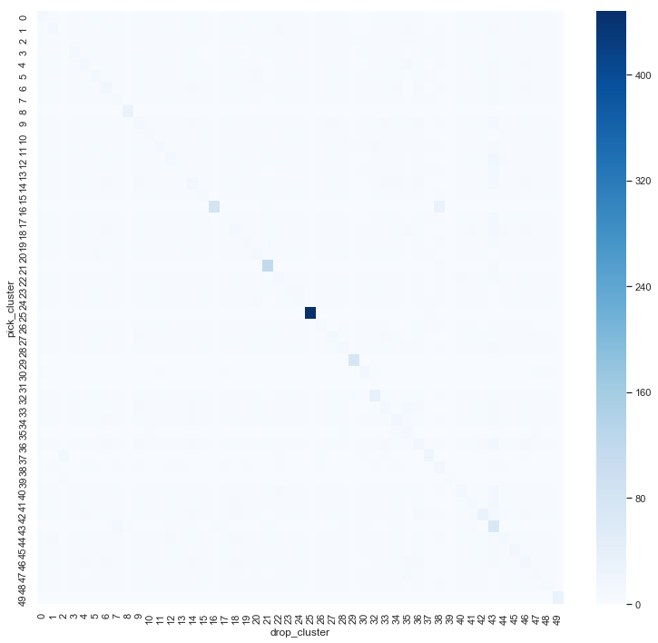

```python
cat = train.groupby(['pick_cluster', 'drop_cluster'],as_index=False)['fare_amount','distance'].agg(['sum']).reset_index()
cat.columns = cat.columns.droplevel(1)
cat = cat[cat['distance'] > 0]
cat['per_km'] = cat['fare_amount']/cat['distance']
#cat = cat[(cat['pick_cluster'] == 3) | (cat['pick_cluster'] == 6)]
cat_pivot = cat.pivot(index='pick_cluster', columns='drop_cluster', values='per_km')
cat_pivot.fillna(0, inplace=True)
plt.figure(figsize=(13,12))
sns.heatmap(cat_pivot,cmap='Blues')
```

**HEATMAP BY PICKUP LOCATION CLUSTER & BEARING**

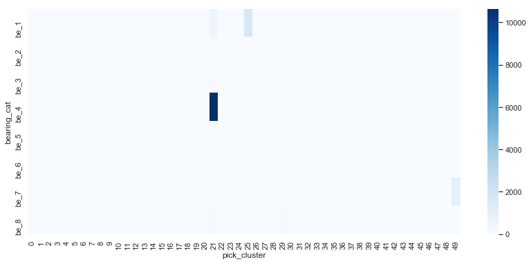

```python
cat = train.groupby(['pick_cluster', 'bearing_cat'],as_index=False)['fare_amount','distance'].agg(['sum']).reset_index()
cat.columns = cat.columns.droplevel(1)
cat = cat[cat['distance'] > 0]
cat['per_km'] = cat['fare_amount']/cat['distance']
#cat = cat[(cat['pick_cluster'] == 3) | (cat['pick_cluster'] == 6)]
cat_pivot = cat.pivot(index='bearing_cat', columns='pick_cluster', values='per_km')
cat_pivot.fillna(0, inplace=True)
plt.figure(figsize=(14,6))
plt.yticks(rotation=0)
sns.heatmap(cat_pivot,cmap='Blues')
plt.show()
```

**BOX PLOT OF FARE AMOUNT WITH RESPECT TO PASSENGER COUNT**

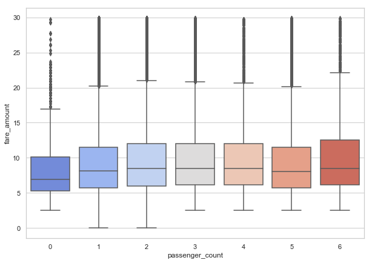

```python
plt.figure(figsize=(10,7))
sns.boxplot(x="passenger_count", y="fare_amount", data=train[(train['distance'] > 0) & (train['passenger_count'] <= 6) &
                (train['fare_amount'] < 30) & (train['fare_amount'] > 0)],palette="coolwarm")
```

**SCATTERPLOT OF FARE AMOUNT WITH RESPECT TO DISTANCE**

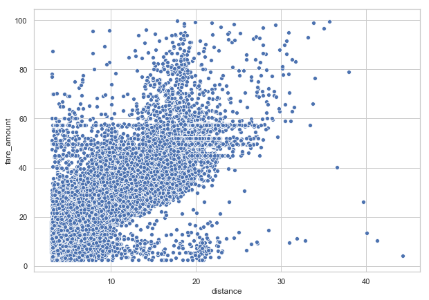

```python
plt.figure(figsize=(10,7))
sns.scatterplot(x="distance", y="fare_amount", data=train[(train['distance'] < 50) & (train['distance'] > 3) &
                                                          (train['fare_amount'] < 100 ) & (train['fare_amount'] > 0 )])
```

We can see that distance, passenger count, day, hour and location clusters all appear to influence the fare a customer pays.

## MODEL PREPERATION & FEATURE SELECTION

**PREPEND CATEGORICAL FEATURES BEFORE CREATING DUMMY VARIABLES**

```python
train['pick_cluster'] = 'pi_' + train['pick_cluster'].astype(str)
test['pick_cluster'] = 'pi_' + test['pick_cluster'].astype(str)
train['drop_cluster'] = 'dr_' + train['drop_cluster'].astype(str)
test['drop_cluster'] = 'dr_' + test['drop_cluster'].astype(str)

test['hour'] = test['hour'].values.astype(np.int64)
test['day'] = test['day'].values.astype(np.int64)
train['hour'] = train['hour'].values.astype(np.int64)
train['day'] = train['day'].values.astype(np.int64)
train['hr'] = 'h' + train['hour'].astype(str)
test['hr'] = 'h' + test['hour'].astype(str)
train['dy'] = 'd' + train['day'].astype(str)
test['dy'] = 'd' + test['day'].astype(str)
```

**CREATE DUMMY VARIABLES**

```python
tr_hr = pd.get_dummies(train['hr'])
te_hr = pd.get_dummies(test['hr'])
tr_dy = pd.get_dummies(train['dy'])
te_dy = pd.get_dummies(test['dy'])
tr_pick = pd.get_dummies(train['pick_cluster'])
te_pick = pd.get_dummies(test['pick_cluster'])
tr_drop = pd.get_dummies(train['drop_cluster'])
te_drop = pd.get_dummies(test['drop_cluster'])
tr_bear = pd.get_dummies(train['bearing_cat'])
te_bear = pd.get_dummies(test['bearing_cat'])
train = pd.concat([train, tr_hr, tr_dy, tr_pick, tr_drop, tr_bear], axis=1)
test = pd.concat([test, te_hr, te_dy, te_pick, te_drop, te_bear], axis=1)
```

```python
train.dropna(inplace=True)
test.dropna(inplace=True)
```

**SELECT TARGET AND DEPENDANT FEATURES**

```python
train_temp = pd.DataFrame(columns = ['distance','passenger_count', 'h0', 'h1',
       'h10', 'h11', 'h12', 'h13', 'h14', 'h15', 'h16', 'h17', 'h18', 'h19',
       'h2', 'h20', 'h21', 'h22','h23', 'h3', 'h4', 'h5', 'h6', 'h7', 'h8','d0',
       'd1', 'd2', 'd3', 'd4', 'd5','be_1', 'be_2', 'be_3', 'be_4', 'be_5', 'be_6', 'be_7'
       'pi_0', 'pi_1', 'pi_10', 'pi_11', 'pi_12', 'pi_13', 'pi_14', 'pi_15',
       'pi_16', 'pi_17', 'pi_18', 'pi_19', 'pi_2', 'pi_20', 'pi_21', 'pi_22',
       'pi_23', 'pi_24', 'pi_25', 'pi_26', 'pi_27', 'pi_28', 'pi_29', 'pi_3',
       'pi_30', 'pi_31', 'pi_32', 'pi_33', 'pi_34', 'pi_35', 'pi_36', 'pi_37',
       'pi_38', 'pi_39', 'pi_4', 'pi_40', 'pi_41', 'pi_42', 'pi_43', 'pi_44',
       'pi_45', 'pi_46', 'pi_47', 'pi_48', 'pi_49', 'pi_5', 'pi_6', 'pi_7',
       'pi_8', 'dr_0', 'dr_1', 'dr_10', 'dr_11', 'dr_12', 'dr_13', 'dr_14', 'dr_15',
       'dr_16', 'dr_17', 'dr_18', 'dr_19', 'dr_2', 'dr_20', 'dr_21', 'dr_22',
       'dr_23', 'dr_24', 'dr_25', 'dr_26', 'dr_27', 'dr_28', 'dr_29', 'dr_3',
       'dr_30', 'dr_31', 'dr_32', 'dr_33', 'dr_34', 'dr_35', 'dr_36', 'dr_37',
       'dr_38', 'dr_39', 'dr_4', 'dr_40', 'dr_41', 'dr_42', 'dr_43', 'dr_44',
       'dr_45', 'dr_46', 'dr_47', 'dr_48', 'dr_49', 'dr_5', 'dr_6', 'dr_7',
       'dr_8'])
X_train = pd.concat([train_temp, train], axis=0)
X_train = X_train[['distance','passenger_count','h0', 'h1',
       'h10', 'h11', 'h12', 'h13', 'h14', 'h15', 'h16', 'h17', 'h18', 'h19',
       'h2', 'h20', 'h21', 'h22','h23', 'h3', 'h4', 'h5', 'h6', 'h7', 'h8','d0',
       'd1', 'd2', 'd3', 'd4', 'd5','be_1', 'be_2', 'be_3', 'be_4', 'be_5', 'be_6', 'be_7'
       'pi_0', 'pi_1', 'pi_10', 'pi_11', 'pi_12', 'pi_13', 'pi_14', 'pi_15',
       'pi_16', 'pi_17', 'pi_18', 'pi_19', 'pi_2', 'pi_20', 'pi_21', 'pi_22',
       'pi_23', 'pi_24', 'pi_25', 'pi_26', 'pi_27', 'pi_28', 'pi_29', 'pi_3',
       'pi_30', 'pi_31', 'pi_32', 'pi_33', 'pi_34', 'pi_35', 'pi_36', 'pi_37',
       'pi_38', 'pi_39', 'pi_4', 'pi_40', 'pi_41', 'pi_42', 'pi_43', 'pi_44',
       'pi_45', 'pi_46', 'pi_47', 'pi_48', 'pi_49', 'pi_5', 'pi_6', 'pi_7',
       'pi_8', 'dr_0', 'dr_1', 'dr_10', 'dr_11', 'dr_12', 'dr_13', 'dr_14', 'dr_15',
       'dr_16', 'dr_17', 'dr_18', 'dr_19', 'dr_2', 'dr_20', 'dr_21', 'dr_22',
       'dr_23', 'dr_24', 'dr_25', 'dr_26', 'dr_27', 'dr_28', 'dr_29', 'dr_3',
       'dr_30', 'dr_31', 'dr_32', 'dr_33', 'dr_34', 'dr_35', 'dr_36', 'dr_37',
       'dr_38', 'dr_39', 'dr_4', 'dr_40', 'dr_41', 'dr_42', 'dr_43', 'dr_44',
       'dr_45', 'dr_46', 'dr_47', 'dr_48', 'dr_49', 'dr_5', 'dr_6', 'dr_7',
       'dr_8']]
y_train = train['fare_amount']
test_temp = pd.DataFrame(columns = ['distance','passenger_count', 'h0', 'h1',
       'h10', 'h11', 'h12', 'h13', 'h14', 'h15', 'h16', 'h17', 'h18', 'h19',
       'h2', 'h20', 'h21', 'h22','h23', 'h3', 'h4', 'h5', 'h6', 'h7', 'h8','d0',
       'd1', 'd2', 'd3', 'd4', 'd5','be_1', 'be_2', 'be_3', 'be_4', 'be_5', 'be_6', 'be_7'
       'pi_0', 'pi_1', 'pi_10', 'pi_11', 'pi_12', 'pi_13', 'pi_14', 'pi_15',
       'pi_16', 'pi_17', 'pi_18', 'pi_19', 'pi_2', 'pi_20', 'pi_21', 'pi_22',
       'pi_23', 'pi_24', 'pi_25', 'pi_26', 'pi_27', 'pi_28', 'pi_29', 'pi_3',
       'pi_30', 'pi_31', 'pi_32', 'pi_33', 'pi_34', 'pi_35', 'pi_36', 'pi_37',
       'pi_38', 'pi_39', 'pi_4', 'pi_40', 'pi_41', 'pi_42', 'pi_43', 'pi_44',
       'pi_45', 'pi_46', 'pi_47', 'pi_48', 'pi_49', 'pi_5', 'pi_6', 'pi_7',
       'pi_8', 'dr_0', 'dr_1', 'dr_10', 'dr_11', 'dr_12', 'dr_13', 'dr_14', 'dr_15',
       'dr_16', 'dr_17', 'dr_18', 'dr_19', 'dr_2', 'dr_20', 'dr_21', 'dr_22',
       'dr_23', 'dr_24', 'dr_25', 'dr_26', 'dr_27', 'dr_28', 'dr_29', 'dr_3',
       'dr_30', 'dr_31', 'dr_32', 'dr_33', 'dr_34', 'dr_35', 'dr_36', 'dr_37',
       'dr_38', 'dr_39', 'dr_4', 'dr_40', 'dr_41', 'dr_42', 'dr_43', 'dr_44',
       'dr_45', 'dr_46', 'dr_47', 'dr_48', 'dr_49', 'dr_5', 'dr_6', 'dr_7',
       'dr_8'])
X_test = pd.concat([test_temp, test], axis=0)
X_test = X_test[['distance','passenger_count', 'h0', 'h1',
       'h10', 'h11', 'h12', 'h13', 'h14', 'h15', 'h16', 'h17', 'h18', 'h19',
       'h2', 'h20', 'h21', 'h22','h23', 'h3', 'h4', 'h5', 'h6', 'h7', 'h8','d0',
       'd1', 'd2', 'd3', 'd4', 'd5','be_1', 'be_2', 'be_3', 'be_4', 'be_5', 'be_6', 'be_7'
       'pi_0', 'pi_1', 'pi_10', 'pi_11', 'pi_12', 'pi_13', 'pi_14', 'pi_15',
       'pi_16', 'pi_17', 'pi_18', 'pi_19', 'pi_2', 'pi_20', 'pi_21', 'pi_22',
       'pi_23', 'pi_24', 'pi_25', 'pi_26', 'pi_27', 'pi_28', 'pi_29', 'pi_3',
       'pi_30', 'pi_31', 'pi_32', 'pi_33', 'pi_34', 'pi_35', 'pi_36', 'pi_37',
       'pi_38', 'pi_39', 'pi_4', 'pi_40', 'pi_41', 'pi_42', 'pi_43', 'pi_44',
       'pi_45', 'pi_46', 'pi_47', 'pi_48', 'pi_49', 'pi_5', 'pi_6', 'pi_7',
       'pi_8', 'dr_0', 'dr_1', 'dr_10', 'dr_11', 'dr_12', 'dr_13', 'dr_14', 'dr_15',
       'dr_16', 'dr_17', 'dr_18', 'dr_19', 'dr_2', 'dr_20', 'dr_21', 'dr_22',
       'dr_23', 'dr_24', 'dr_25', 'dr_26', 'dr_27', 'dr_28', 'dr_29', 'dr_3',
       'dr_30', 'dr_31', 'dr_32', 'dr_33', 'dr_34', 'dr_35', 'dr_36', 'dr_37',
       'dr_38', 'dr_39', 'dr_4', 'dr_40', 'dr_41', 'dr_42', 'dr_43', 'dr_44',
       'dr_45', 'dr_46', 'dr_47', 'dr_48', 'dr_49', 'dr_5', 'dr_6', 'dr_7',
       'dr_8']]
y_test = test['fare_amount']
```

```python
X_train.fillna(0,inplace=True)
X_test.fillna(0,inplace=True)
```

## MODEL BUILD

#### SPLIT TEST SET INTO TEST & VALIDATION SET

```python
X_val, X_test, y_val, y_test = train_test_split(X_test, y_test, test_size=0.5, random_state=101)
eval_set = [(X_train, y_train),(X_val, y_val)]
```

### TRAIN XGBOOST MODEL USING GRID SEARCH TO FIND HYPERPARAMETERS

For this project we will use XGBoost to predict the target variable. XGBoost is an gradient boosting method that has proven to be accurate over a number of different types of prediction competitions and is optimised for multithreading meaning training and prediction is much faster than comparable models.

Boosting models train using a random selection of fields and training examples to build trees that are optimised to reduce the error between the output of the tree for the training examples and training target. The model builds trees sequentially and as each tree is built the examples with the largest errors are given larger weights which ensures the next tree built effectivly pays more attention to these examples when optimising. Any prediction example is effectively passed through all the trees in the final model with the output of each tree either averaged (regression) or voted (classification) to produce a prediction.

#### GRID SEARCH

Use sample data sets to determine best parameters for use in final XGBoost model

```python
from sklearn.model_selection import GridSearchCV
import xgboost as xgb
xgb = xgb.XGBRegressor()
xg_grid_search = GridSearchCV(xgb, {"colsample_bytree":[0.3, 0.6, 0.9],"min_child_weight":[1.0, 10.0, 100.0],
                            'max_depth': [3, 6, 9], 'n_estimators': [10000],
                            'learning_rate': [0.1, 0.2, 0.3]}, cv=2)
#Train model with the model stopping early if there hasn't been improvement for 50 epochs
xg_grid_search.fit(X_train, y_train, early_stopping_rounds=50,
                   eval_metric="rmse", eval_set=eval_set, verbose=False)
print(xg_grid_search.best_params_)
```

```
{'colsample_bytree': 0.6, 'learning_rate': 0.1, 'max_depth': 9, 'min_child_weight': 1.0, 'n_estimators': 10000}
```

#### TRAIN XGBOOST MODEL USING HYPERPARAMETERS DERIVED FROM GRID SEARCH

```python
import xgboost as xgb
xgb = xgb.XGBRegressor(colsample_bytree=0.6, learning_rate=0.1, max_depth=9, min_child_weight=1, n_estimators=10000)
xgb.fit(X_train, y_train, early_stopping_rounds=50,
                   eval_metric="rmse", eval_set=eval_set, verbose=False)
```

```
XGBRegressor(base_score=0.5, booster='gbtree', colsample_bylevel=1,
       colsample_bytree=0.6, gamma=0, learning_rate=0.1, max_delta_step=0,
       max_depth=9, min_child_weight=1, missing=None, n_estimators=10000,
       n_jobs=1, nthread=None, objective='reg:linear', random_state=0,
       reg_alpha=0, reg_lambda=1, scale_pos_weight=1, seed=None,
       silent=True, subsample=1)
```

#### USE TRAINED MODEL TO MAKE PREDICTION ON TEST SET & SCORE MODEL BASED ON MAE & RMSE

```python
xg_train_prediction = xgb.predict(X_train)
xg_test_prediction = xgb.predict(X_test)
from sklearn.metrics import mean_absolute_error, mean_squared_error
print('Train MAE: ' + str(mean_absolute_error(y_train, xg_train_prediction)))
print('Train RMSE: ' + str(sqrt(mean_squared_error(y_train, xg_train_prediction))))
print('Test MAE: ' + str(mean_absolute_error(y_test, xg_test_prediction)))
print('Test RMSE: ' + str(sqrt(mean_squared_error(y_test, xg_test_prediction))))
```

```
Train MAE: 1.9693111535499346
Train RMSE: 3.622376757760715
Test MAE: 2.3271091088447493
Test RMSE: 4.755365696747852
```

RMSE of \$4.76 is a large improvement on the \\$9.76 from the benchmark simple linear model

## MODEL ANALYSIS

### FEATURE IMPORTANCE

```python
features = pd.DataFrame(list(X_train.columns.values))
features.rename(columns={0:'features'}, inplace=True)
feature_imp = pd.DataFrame(xgb.feature_importances_)
feature_imp.rename(columns={0:'importance'}, inplace=True)
feature_imp = pd.concat([features,feature_imp],axis=1)
feature_imp.sort_values(by=['importance'],ascending=False, inplace=True)
```

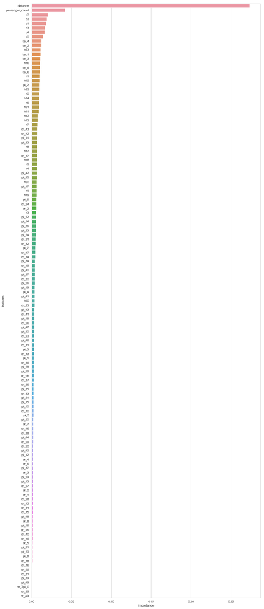

```python
sns.set(style="whitegrid")
plt.subplots(figsize=(15, 40))
sns.barplot(x=feature_imp['importance'], y=feature_imp['features'])
plt.show()
```

As we would expect given the nature of the problem we are trying to solve, distance is by far the most predictive feature in the model but many of the other engineered features appear to offer additional incremental improvements.

### PREDICTION ERRORS

```python
predictions = pd.DataFrame(xg_test_prediction)
predictions.rename(columns={0:'prediction'}, inplace=True)
X_test.reset_index(inplace=True, drop=True)
y_test = pd.DataFrame(y_test)
y_test.rename(columns={0:'fare_amount'}, inplace=True)
y_test.reset_index(inplace=True, drop=True)
predictions = pd.concat([X_test, y_test, predictions], axis=1)
```

```python
predictions['error'] = predictions['fare_amount'] - predictions['prediction']
predictions['absolute_error'] = np.absolute(predictions['error'])
```

#### TOP 10 PREDICTION ERRORS

```python
predictions.sort_values(by=['absolute_error'],ascending=False).head(10)
```

|  | distance | passenger_count | h0 | h1 | h10 | h11 | h12 | h13 | h14 | h15 | h16 | h17 | h18 | h19 | h2 | h20 | h21 | h22 | h23 | h3 | h4 | h5 | h6 | h7 | h8 | d0 | d1 | d2 | d3 | … |
| --- | --- | --- | --- | --- | --- | --- | --- | --- | --- | --- | --- | --- | --- | --- | --- | --- | --- | --- | --- | --- | --- | --- | --- | --- | --- | --- | --- | --- | --- | --- |
| 33737 | 0.006359 | 1 | 0 | 1 | 0 | 0 | 0 | 0 | 0 | 0 | 0 | 0 | 0 | 0 | 0 | 0 | 0 | 0 | 0 | 0 | 0 | 0 | 0 | 0 | 0 | 1 | 0 | 0 | 0 | … |
| 42833 | 84.958171 | 1 | 0 | 0 | 0 | 1 | 0 | 0 | 0 | 0 | 0 | 0 | 0 | 0 | 0 | 0 | 0 | 0 | 0 | 0 | 0 | 0 | 0 | 0 | 0 | 0 | 1 | 0 | 0 | … |
| 41641 | 0.866226 | 1 | 0 | 0 | 0 | 0 | 1 | 0 | 0 | 0 | 0 | 0 | 0 | 0 | 0 | 0 | 0 | 0 | 0 | 0 | 0 | 0 | 0 | 0 | 0 | 0 | 0 | 0 | 0 | … |
| 59574 | 0.000000 | 1 | 0 | 0 | 0 | 0 | 0 | 0 | 0 | 0 | 0 | 0 | 0 | 0 | 0 | 0 | 0 | 0 | 0 | 0 | 0 | 0 | 0 | 0 | 0 | 0 | 1 | 0 | 0 | … |
| 100640 | 3.113096 | 1 | 0 | 0 | 0 | 0 | 1 | 0 | 0 | 0 | 0 | 0 | 0 | 0 | 0 | 0 | 0 | 0 | 0 | 0 | 0 | 0 | 0 | 0 | 0 | 1 | 0 | 0 | 0 | … |
| 105130 | 0.000000 | 2 | 0 | 0 | 0 | 0 | 0 | 0 | 0 | 0 | 0 | 0 | 0 | 0 | 0 | 0 | 0 | 0 | 0 | 0 | 1 | 0 | 0 | 0 | 0 | 0 | 0 | 0 | 0 | … |
| 85811 | 49.987735 | 1 | 0 | 0 | 0 | 0 | 0 | 0 | 0 | 1 | 0 | 0 | 0 | 0 | 0 | 0 | 0 | 0 | 0 | 0 | 0 | 0 | 0 | 0 | 0 | 0 | 0 | 1 | 0 | … |
| 33758 | 0.183339 | 1 | 0 | 0 | 0 | 0 | 0 | 0 | 0 | 0 | 1 | 0 | 0 | 0 | 0 | 0 | 0 | 0 | 0 | 0 | 0 | 0 | 0 | 0 | 0 | 0 | 0 | 0 | 0 | … |
| 49526 | 41.296356 | 2 | 0 | 0 | 0 | 0 | 1 | 0 | 0 | 0 | 0 | 0 | 0 | 0 | 0 | 0 | 0 | 0 | 0 | 0 | 0 | 0 | 0 | 0 | 0 | 0 | 0 | 0 | 1 | … |
| 83685 | 42.730781 | 1 | 0 | 0 | 0 | 0 | 0 | 1 | 0 | 0 | 0 | 0 | 0 | 0 | 0 | 0 | 0 | 0 | 0 | 0 | 0 | 0 | 0 | 0 | 0 | 0 | 0 | 0 | 1 | … |

#### PREDICTION ERROR DISTRIBUTION

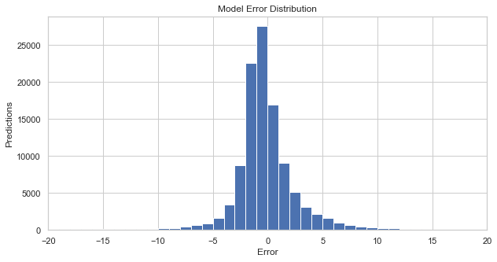

```python
plt.subplots(figsize=(10,5))
plt.xlim(-20, 20)
#plt.ylim(0, 300)
plt.title('Model Error Distribution')
plt.ylabel('Predictions')
plt.xlabel('Error')
plt.hist(predictions['error'], bins=np.linspace(-20, 20, num=41, dtype=int));
plt.show()
```

We can see that in general the errors are normally distributed around $0

## Conclusion

We have seen that by using XGBoost and additional feature engineering we have been able to improve the RMSE from \$9.76 to \\$4.76 against the benchmark linear model. This is using only a 1% sample of the provided training data to build the model and test.

As a following stage to improve the accuracy of this model we could look to include some or all of the following:

- Analyse test examples with the largest errors to determine any visible patterns and if these can be used to create new features
- Use a larger sample of the provided training data to train the model
- Train a deep learning model which have been shown to provide significant improvements in many cases